# Notebook

### Какие товары приносят прибыль, а какие - убытки и что делать с этим (ABC-XYZ анализ)

#### Цель проекта

Определить, какие товары генерируют основную прибыль и где скрыты риски нестабильного спроса. Предложить действия для оптимизации ассортимента с минимальными затратами.

#### Критический инсайт

76.5% маржинальной прибыли генерируется всего тремя товарами. При всем при этом спрос на эти товары нестабилен. Требуется усиленный контроль запасов и диверсификация рисков.

#### Ключевые инсайты

1. **Три товара тянут бизнес, но они ненадежны:** "Беспроводные наушники", "Умная колонка" и "Ортопедическая подушка" генерируют 76.5% прибыли, но при этом продажи скачут - в некоторые недели спрос падает на 11-20%, а в некоторые - растет. Если в пик спроса товар не окажется на складе, бизнес потеряет львиную долю прибыли.
2. **Один стабильный товар для масштабирования:** позиция "Джинсы классические" - единственный товар с предсказуемым спросом из ассортимента (отклонение менее 10%). Является идеальным кандидатом для масштабирования.
3. **"Футболка оверсайз" и ее "нестабильность":** формально эта позиция показывает хаотичный спрос (61% отклонения), но если мы исключим те 18 дней, когда товар отсутствовал на складе, мы получим реальное отклонение спроса в 9.6%. Несмотря на трехнедельное отсутствие, товар продемонстрировал стабильный спрос за следующие семь недель.
4. **"Платье летнее" - низкомаржинальный товар с сезонным характером:** "Платье летнее" имеет ярко выраженный сезонный спрос. Нет смысла держать товар на складе круглый год, платя за его хранение.

#### Рекомендации

1. Прежде чем увеличивать страховые запасы трех наших главных товаров по прибыли, **нужно изучить природу нестабильного спроса**. Необходимо проанализировать причины нестабильности: действия конкурентов, изменения в ранжировании на маркетплейсе, сезонность товара и так далее. Если причина во внешних факторах (акции, сезонность) - увеличенный запас оправдан. Если причина в падении интереса к товару - не увеличивать запас, а работать с карточкой продавца.
2. В случае влияния внешних факторов на стабильность спроса, при следующей закупке **протестировать увеличение размера партии на 20-30% для "Умной колонки"** (спрос на нее самый нестабильный в этой категории - почти 20% отклонения). Проверяем, покрывает ли увеличенный запас пики спроса. Также проверяем, сколько дополнительной прибыли получено за счет того, что товар был в наличии в моменты скачков спроса, достаточно ли у нас оставалось запасов, а также сколько денег "заморозилось" в лишнем товаре. На основе этого принимаем решение о необходимости или отсутствии необходимости увеличить запасы товара на складе.
3. **Протестировать гипотезу с расширением ассортимента для позиции "Джинсы классические"** (например, черные джинсы или другие максимально близкие варианты). Закупить минимальную партию, запустить на продажу. Мониторим конверсию и спрос в течение 2-4 недель. Если черные джинсы продаются со скоростью примерно 75-80% относительно классических - масштабируемся, если ниже 50% - выводим из продажи и больше не закупаем, минимальные потери.
4. Несмотря на фактически высокий спрос позиции "Футболка оверсайз" (когда она есть на складе), бизнес-модель товара убыточна. **Необходимо проверить, возможно ли математически сделать товар прибыльным:** повысить цену на 15-20% на 1-2 дня, чтобы проверить спрос или попробовать сбить себестоимость на 10-15%. Если математика не сходится, распродаем товар по себестоимости и выводим из ассортимента. Если математика сходится, делаем только один минимальный заказ. Если метрики не улучшаются, распродаем по себестоимости и выводим из ассортимента.
5. Поднять маржинальность товаров "Худи базовое" и "Органайзер для белья". **Протестировать поэтапное повышение цены на 1-2% для одной из позиций** с мониторингом общей прибыли и количества заказов в течение 3-4 дней. Повторяем до достижения маржинальности 15-20% для товара. Если происходит снижение общих заказов на 30-40%, откатываем на последний успешный шаг. **Альтернатива - протестировать бандлы:** продавать товар в связке с более маржинальными товарами. Если после 2-3 итераций тестов не удается поднять маржинальность на 15-20% без критического падения спроса (более 30%), то рассматриваем вывод этих позиций из ассортимента и замену на аналоги с лучшей юнит-экономикой.
6. Товар "Платье летнее" имеет ярко выраженный и предсказуемый сезонный спрос. **Необходимо распродать и вывести товар из ассортимента вне сезона, но в дальнейшем закупить товар небольшой партией перед началом сезона (апрель-май) для проверки спроса и маржинальности.** Если в сезон маржинальность не будет достигать хотя бы 15-20%, то исключаем товар окончательно.

Рейтинг маржинальности (A - лучшее, C - худшее, D - убыточное)

|  | Артикул | Название товара | Маржинальная прибыль (руб.) | Накопленная прибыль (руб.) | Накопленный % | Класс ABC |
| --- | --- | --- | --- | --- | --- | --- |
| 0 | EL-001 | Беспроводные наушники TWS | 135,000 | 135,000 | 31.8 | A |
| 1 | EL-002 | Умная колонка | 114,000 | 249,000 | 58.6 | A |
| 2 | HO-001 | Ортопедическая подушка | 76,000 | 325,000 | 76.5 | A |
| 3 | CL-002 | Джинсы классические | 25,000 | 350,000 | 82.4 | B |
| 4 | HO-002 | Набор кухонных ножей | 22,000 | 372,000 | 87.5 | B |
| 5 | EL-003 | Портативная зарядка 20000mAh | 18,000 | 390,000 | 91.8 | B |
| 6 | CL-003 | Худи базовое | 15,000 | 405,000 | 95.3 | C |
| 7 | HO-003 | Органайзер для белья | 12,000 | 417,000 | 98.1 | C |
| 8 | CL-004 | Платье летнее | 8,000 | 425,000 | 100.0 | C |
| 9 | CL-001 | Футболка оверсайз (XL) | -15,000 | nan | nan | D |

Рейтинг стабильности спроса (X - самое стабильное, Z - самое нестабильное)

|  | Артикул | Название товара | Средние продажи (шт/нед) | Станд. отклонение | Коэф. вариации (CV, %) | Класс XYZ |
| --- | --- | --- | --- | --- | --- | --- |
| 0 | CL-002 | Джинсы классические | 63.1 | 6.0 | 9.4 | X |
| 1 | EL-001 | Беспроводные наушники TWS | 126.3 | 20.6 | 16.3 | Y |
| 2 | EL-002 | Умная колонка | 49.1 | 9.7 | 19.7 | Y |
| 3 | EL-003 | Портативная зарядка 20000mAh | 33.7 | 7.9 | 23.4 | Y |
| 4 | HO-001 | Ортопедическая подушка | 53.6 | 6.1 | 11.4 | Y |
| 5 | HO-002 | Набор кухонных ножей | 43.1 | 7.6 | 17.6 | Y |
| 6 | HO-003 | Органайзер для белья | 27.5 | 5.2 | 19.0 | Y |
| 7 | CL-003 | Худи базовое | 50.3 | 5.7 | 11.3 | Y |
| 8 | CL-001 | Футболка оверсайз (XL) | 31.2 | 19.2 | 61.3 | Z |
| 9 | CL-004 | Платье летнее | 43.3 | 18.4 | 42.5 | Z |

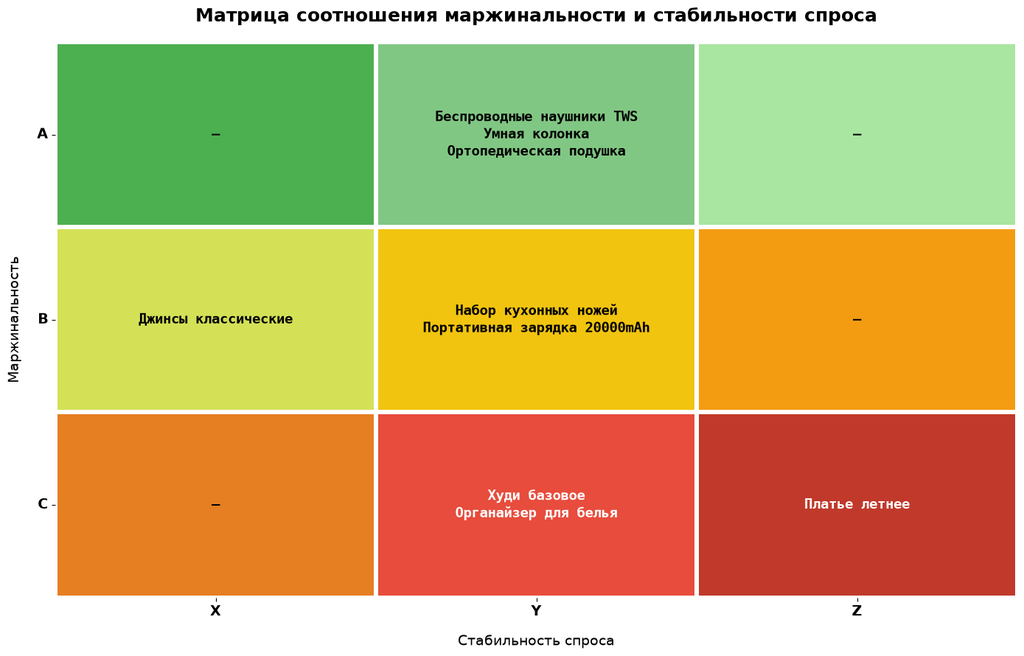